# WeRateDogs Dataset Report

### Liam Cottrell

Computers, the pioneering medium of the modern technological age, are now a thing of the past. Well, when it comes to updating the world on our furry friends they are anyway, with a whopping 98% of people opting instead to upload directly from their iPhones, as opposed to tweetdeck or the old fashioned computers. Tough on the older generation...it appears you just can't teach an old dog new tricks.

Enough source, onto the mains, with the Golden Retriever taking 1st place for upload count, followed by his distant relation the labrador retreiver. A proud day for all in the retriever household. Regarding the dog stages, it's apparent what dog owners want the world of WeRateDogs to see gazing up from their iphones: puppers. The little guys scored more than three times as many tweets as their nearest rivals, the doggos. Meanwhile Puppos (the dog equivalent of teens), and Floofers (the hairy mutts) scored 3rd and fourth place respectively, proving what we knew all expected: hairy babies are not popular on Twitter. Not even in dog form. Ruff.

[figure not shown]

What we want to know most though is how popular these little guys are. After all, as Facebook has proved once before, just because every man and his dog is uploading a baby pic, it doesn't mean people actually WANT to see it. After initially barking up the wrong tree with the delightful yet entirely unuseful WeRateDogs ratings, I instead decided to use the retweet count and favourite count to get a better measure of a given dog's popularity on the platform.

Both retweets and favourites serve very similar functions in the world of twitter. Essentially, they are a means of the audience signalling approval for a given tweet. Therefore it wasn't such a surprise to see the graph of retweet count vs favourite count come out linearly. As a result of this, both mean retweet count and mean favourite count showed almost identical correlations with the mean dog stage, as you can see below.

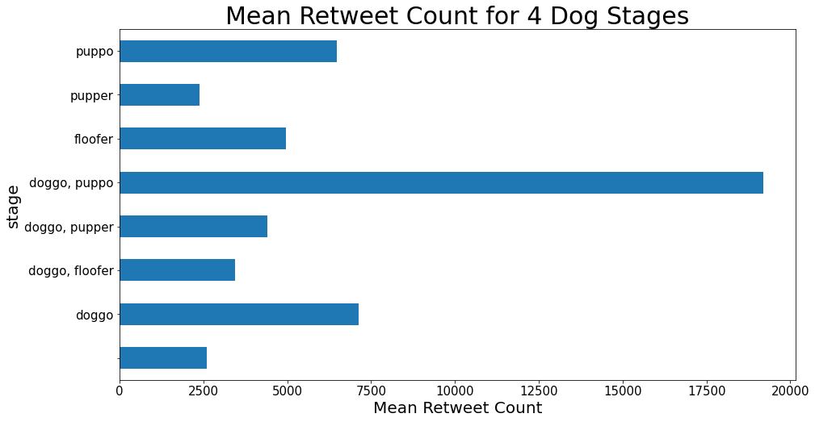

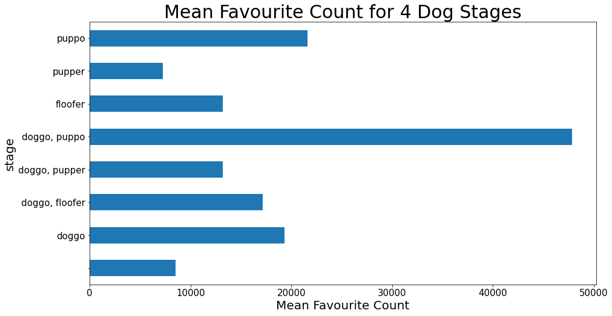

It seems puppos and doggos together are a winning combination, though this is based off of only a few data points so the results are tentative. We can have more confidence in the ratings for the individual stages, and once again, it's the puppos and doggos that ran away with it, leaving floofers and puppers chasing their tail. Despite the little puppos winning the favourite count race convincingly, the doggos actually slightly outscored their younger counterparts this time when came to mean retweet count. You could say they were...pupped at the post. (I'm genuinely sorry for that one.)

All in all, due to their proportionally higher favourite count, I can offically declare the WeRateDogs king of twitter to be...Puppos! Special shoutout to all the golden retriever puppos out there, you're making your families proud. A side note for any potential dog uploaders- we don't want to see your babies, but if you insist, a little grooming goes a long way.

[figure not shown]